# KGF Grind and Inject Pressure & Volume History

Kenai gas field has two wells that are permitted as Class 1 disposal, KU 12-17 and KU 24-7RD. Find their EPA Permit here [Permit Number AK-1I018-A](https://www.epa.gov/system/files/documents/2021-09/uic-permit-r10-ak1i018a-2021.pdf). Both wells have been starting to “pressure up” when disposing of drill well cuttings (and other oil field waste). The injection pressure limits can be found on page #14 of the EPA permit under Well Operation - Section 4 - Injection Pressure Limitation:

##### **Injection Pressure Limitation**

The Permittee must not inject at a pressure that initiates new fractures or propagates existing fractures in the injection zone or the upper confining zone, as described in the Fact Sheet. **The Permittee must not inject at a pressure exceeding the maximum injection pressure of 2200 psi, measured at the wellhead**, except as follows:

1. If a plant is shut-down or outage (unrelated to fluid injection activities) occurs.
2. If a well stimulation is required.

In such instances, the **Permittee must notify the Director or an EPA authorized representative by telephone or email within 24 hours of the initial exceedance of 2200 psi** and must submit a written incident report not later than 10 calendar days thereafter. The Permittee must never inject above the working pressure for which the well components are rated.

##### **Gathering the trend data**

We want to know what is the average injection pressure, pump rate, and total volume of each injection cycle.

A raw view of the injection cycles as they appear in ‘Trend’ software is shown below.

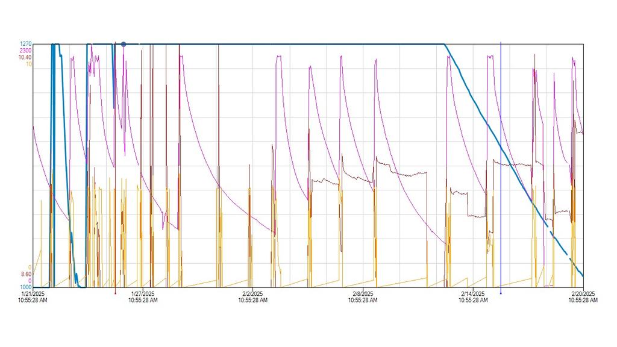

##### SCADA Tags

- KU 12-17
- Mass Flow Rate: AK_4118_Well_KU_1217.Mass_FR
- Injection Tubing Pressure: AK_4118_Well_KU_1217.TBG_PT
- KU 24-07RD
- Mass Flow Rate: AK_4118_Well_KU_247RD.Mass_FR
- Injection Tubing Pressure: AK_4118_Well_KU_247RD.TBG_PT

|  | Well | Tag | DateTime | Value |
| --- | --- | --- | --- | --- |
| 1 | none | none | 2024-12-01 09:38:00.0000000 | 0.8167028 |
| 2 | none | none | 2024-12-01 09:39:00.0000000 | 2.0023026 |
| 3 | none | none | 2024-12-01 09:40:00.0000000 | 3.8584342 |
| 4 | none | none | 2024-12-01 09:41:00.0000000 | 3.9700847 |
| 5 | none | none | 2024-12-01 09:42:00.0000000 | 4.0330548 |
| 6 | none | none | 2024-12-01 09:43:00.0000000 | 3.9647455 |
| 7 | none | none | 2024-12-01 09:44:00.0000000 | 4.0327411 |
| 8 | none | none | 2024-12-01 09:45:00.0000000 | 3.9744816 |
| 9 | none | none | 2024-12-01 09:46:00.0000000 | 4.0278730 |
| 10 | none | none | 2024-12-01 09:47:00.0000000 | 3.9886146 |

[output cut: 110 more lines]